# Tidy Data with Python

Juan C. Correa

2024-11-07

```python
import pandas as pd
base_url = "https://github.com/byuidatascience/data4python4ds/raw/master/data-raw/"
table1 = pd.read_csv("{}table1/table1.csv".format(base_url))
table2 = pd.read_csv("{}table2/table2.csv".format(base_url))
table3 = pd.read_csv("{}table3/table3.csv".format(base_url))
table4a = pd.read_csv("{}table4a/table4a.csv".format(base_url))
table4b = pd.read_csv("{}table4b/table4b.csv".format(base_url))
```

La Tabla 1 (`table1`) viene así

```python
table1
```

```
##        country  year   cases  population
## 0  Afghanistan  1999     745    19987071
## 1  Afghanistan  2000    2666    20595360
## 2       Brazil  1999   37737   172006362
## 3       Brazil  2000   80488   174504898
## 4        China  1999  212258  1272915272
## 5        China  2000  213766  1280428583
```

La Tabla 2 (`table2`) tiene esta apariencia

```python
table2
```

```
##         country  year        type       count
## 0   Afghanistan  1999       cases         745
## 1   Afghanistan  1999  population    19987071
## 2   Afghanistan  2000       cases        2666
## 3   Afghanistan  2000  population    20595360
## 4        Brazil  1999       cases       37737
## 5        Brazil  1999  population   172006362
## 6        Brazil  2000       cases       80488
## 7        Brazil  2000  population   174504898
## 8         China  1999       cases      212258
## 9         China  1999  population  1272915272
## 10        China  2000       cases      213766
## 11        China  2000  population  1280428583
```

La Tabla 3 (`table3`) es algo distinta

```python
table3
```

```
##        country  year               rate
## 0  Afghanistan  1999       745/19987071
## 1  Afghanistan  2000      2666/20595360
## 2       Brazil  1999    37737/172006362
## 3       Brazil  2000    80488/174504898
## 4        China  1999  212258/1272915272
## 5        China  2000  213766/1280428583
```

La tabla 4a (`table4a`) también es algo diferente

```python
table4a
```

```
##        country    1999    2000
## 0  Afghanistan     745    2666
## 1       Brazil   37737   80488
## 2        China  212258  213766
```

Y lo mismo podemos afirmar de la tabla 4b (`table4b`)

```python
table4b
```

```
##        country        1999        2000
## 0  Afghanistan    19987071    20595360
## 1       Brazil   172006362   174504898
## 2        China  1272915272  1280428583
```

y de la tabla 5 (`table5`)

```python
table5 = pd.read_csv("{}table5/table5.csv".format(base_url), dtype = 'object')
table5
```

```
##        country century year               rate
## 0  Afghanistan      19   99       745/19987071
## 1  Afghanistan      20   00      2666/20595360
## 2       Brazil      19   99    37737/172006362
## 3       Brazil      20   00    80488/174504898
## 4        China      19   99  212258/1272915272
## 5        China      20   00  213766/1280428583
```

La recomendación estándar para analizar datos estructurados es que cada variable debe ocupar una columna, cada observación debe ocupar una fila o renglón, y los valores de cada observación deben estar en cada celda, tal como aparece en la siguiente imágen.

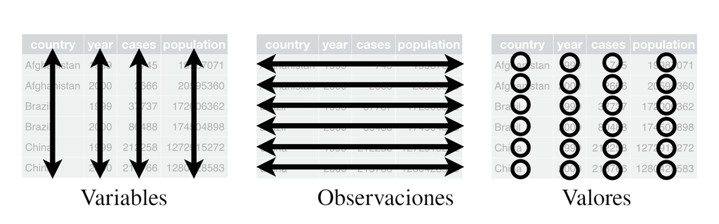

Estas tres reglas están interrelacionadas porque es imposible satisfacer solo dos de las tres. Esa interrelación conduce a un conjunto aún más simple de instrucciones prácticas:

Coloque cada conjunto de datos en un objeto de tipo tibble. Coloque cada variable en una columna.

En este ejemplo, solo la tabla 1 está ordenada. Es la única representación donde cada columna es una variable.

¿Por qué es importante tener los datos ordenados?

La ventaja general es tener una forma consistente de almacenar datos. Si tiene una estructura de datos consistente, es más fácil aprender las herramientas que funcionan con ella porque tienen una uniformidad subyacente. La ventaja específica en colocar variables en columnas es que permite que la naturaleza vectorizada de pandas y NumPy brille.

Las librerías “altair” y “Pandas” funcionan bien con datos ordenados. Aquí hay un par de pequeños ejemplos que muestran cómo podría trabajar con la tabla 1.

```python
import altair as alt
table1.assign(
  rate = lambda x: x.cases / x.population * 1000
)
```

```
##        country  year   cases  population      rate
## 0  Afghanistan  1999     745    19987071  0.037274
## 1  Afghanistan  2000    2666    20595360  0.129447
## 2       Brazil  1999   37737   172006362  0.219393
## 3       Brazil  2000   80488   174504898  0.461236
## 4        China  1999  212258  1272915272  0.166750
## 5        China  2000  213766  1280428583  0.166949
```

```python
(table1.
  groupby('year').
  agg(n = ('cases', 'sum')).
  reset_index())
```

```
##    year       n
## 0  1999  250740
## 1  2000  296920
```

```python
base_chart = (alt.Chart(table1).
              encode(alt.X('year'), alt.Y('cases'), detail = 'country'))

chart = base_chart.mark_line() + base_chart.encode(color = 'country').mark_circle()

chart
```

[output not shown]